# 5 INSTANCE BASED LEARNING

#### Parametric vs Non-parametric Models

**Parametric Models**

- In the models that we have seen, we select a hypothesis space $\mathcal{H}$ and adjust a *fixed set of parameters* $\boldsymbol{{\color{red}w}}$ with the training data $\mathcal{D}$
- We assume that the parameters $\boldsymbol{{\color{red}w}}$ summarize the training data $\mathcal{D}$ and we can forget about it

**Non-parametric Models**

- A non parametric model is one that can not be characterized by a fixed set of parameters
- A family of non parametric models is **Instance Based Learning**. The function is based on the training data $\mathcal{D}=\{\boldsymbol{x}_{1},\boldsymbol{x}_{2},...\boldsymbol{x}_{n}\}$

$$\begin{equation}
y=f(\boldsymbol{x};{\color{red}\boldsymbol{w}})
\end{equation}$$

$$\begin{equation}
y=f(\boldsymbol{x};\boldsymbol{x}_{1},\boldsymbol{x}_{2},...,\boldsymbol{x}_{n})
\end{equation}$$

#### Inductive Bias

In nonparametric model, we assume that *similar* *inputs have* *similar* *outputs*.

- This is a reasonable assumption: The world is smooth, and functions, whether they are densities, discriminants, or regression functions, change slowly. Similar instances mean similar things.

## 5.1 Classification

### k-Nearest Neighbor (k-NN)

#### When To Consider Nearest Neighbor

- Data points $\boldsymbol{x}\in\mathbb{R}^{D}$
- Less than $D<20$ attributes
- Lots of training data $\mathcal{D}$

#### Nearest Neighbor

**Learning mode**

- Store all training examples $\mathcal{D}=\{(\boldsymbol{x}_{i},y_{i})\mid i=1,...,N\}$

**Running mode**

- **Nearest neighbor**: Given query instance $\boldsymbol{x}_{q}$, first locate *the nearest neighbhor* $\boldsymbol{x}^{(1)}$, then estimate
  $$\begin{equation}
  h(\boldsymbol{x}_{q})=y^{(1)}
  \end{equation}$$
- **${\color{green}k}$-Nearest neighbor**: Given $\boldsymbol{x}_{q}$, take vote among its ${\color{green}k}$ *nearest neighbors* $\{\boldsymbol{x}^{(1)},\boldsymbol{x}^{(2)},...,\boldsymbol{x}^{({\color{green}k})}\}$
  $$\begin{equation}
  h(\boldsymbol{x}_{q})=\text{majority vote}\{y^{(1)},y^{(2)},...,y^{({\color{green}k})}\}
  \end{equation}$$

#### Distance

Some common distances in space $\mathbb{R}^{D}$

- The Minkowski distance of order $p>0$
  $$\begin{equation}
  d(\boldsymbol{x},\boldsymbol{y})=L_{p}(\boldsymbol{x},\boldsymbol{y})=\left(\sum_{i=1}^{D}|x_{i}-y_{i}|^{p}\right)^{1/p}
  \end{equation}$$
- Euclidean distance (popular)
  $$\begin{equation}
  d(\boldsymbol{x},\boldsymbol{y})=L_{2}(\boldsymbol{x},\boldsymbol{y})=\sqrt{\sum_{i=1}^{D}(x_{i}-y_{i})^{2}}
  \end{equation}$$
- Manhattan distance
  $$\begin{equation}
  d(\boldsymbol{x},\boldsymbol{y})=L_{1}(\boldsymbol{x},\boldsymbol{y})=\sum_{i=1}^{D}|x_{i}-y_{i}|
  \end{equation}$$
- Contours of the distance from the origin O for various values of the parameter $p$

[figure not shown]

#### The Curse of dimensionality

- The more dimensions we have, the more examples we need
- The number of examples that we have in a volume of space *decreases exponentially* with the number of dimensions
  - If the number of dimensions is very high, the nearest neighbours can be very far away

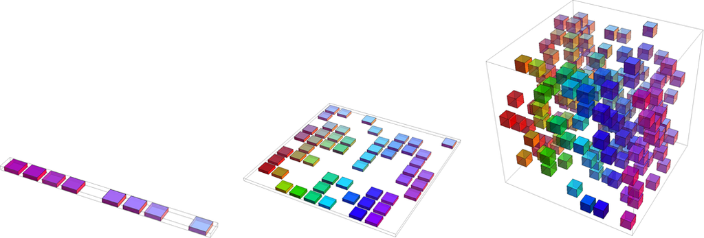

#### Analysis

**Advantages**

- No training, just store data
- Learn complex target functions
- Don’t lose information

**Disadvantages**

- Slow at query time
- Easily fooled by irrelevant attributes

### Effects of Hyper-parameters

#### Parameter k

- if $k=1$ the *cross point $\boldsymbol{x}$* should be classified to *square class*
- if $k=3$ ?
- if $k=5$ ?

[figure not shown]

- Data set $\mathcal{D}$ with 500 samples belonging to two classes {blue, orange}

[figure not shown]

- Decision regions for various values of ${\color{green}k}$

[figure not shown]

## 5.2 Metric Learning

### Motivation

#### Motivation

- Nearest neighbor classification

[figure not shown]

- Clustering

[figure not shown]

- Information retrieval

[figure not shown]

- Data visualization

[figure not shown]

### Metric Learning

#### Metric Learning

- Given a set of data points $\mathcal{X}$ and their corresponding labels $\mathcal{Y}$
- Select a parametric distance or similarity function
  $$\begin{equation}
  d_{{\color{red}W}}(\boldsymbol{x},\boldsymbol{x}')=L\left(f_{{\color{red}W}}(\boldsymbol{x}),f_{{\color{red}W}}(\boldsymbol{x}')\right)
  \end{equation}$$
  - An embedding function (parametric function)
    $$\begin{equation}
    f_{{\color{red}W}}(\boldsymbol{x})\colon\mathcal{X}\to\mathbb{R}^{n}
    \end{equation}$$
  - A distance function (which is usually fixed beforehand)
    $$\begin{equation}
    L(\boldsymbol{x},\boldsymbol{x}')\colon\mathbb{R}^{n}\times\mathbb{R}^{n}\to\mathbb{R}
    \end{equation}$$
- The goal is to train the parametric distance, so that the combination $d_{{\color{red}W}}(\boldsymbol{x},\boldsymbol{x}')$ produces small values if the labels $y,y'\in\mathcal{Y}$ of the samples $\boldsymbol{x},\boldsymbol{x}'\in\mathcal{X}$ are equal, and larger values if they aren’t.
- Collect similarity judgements on data pairs/triplets
  $$\begin{align}
  \mathcal{S} & = & \{(\boldsymbol{x}_{i},\boldsymbol{x}_{j}):\boldsymbol{x}_{i}\text{ and }\boldsymbol{x}_{j}\text{ should be similar}\},\nonumber \\
  \mathcal{D} & = & \{(\boldsymbol{x}_{i},\boldsymbol{x}_{j}):\boldsymbol{x}_{i}\text{ and }\boldsymbol{x}_{j}\text{ should be dissimilar}\}.\\
  \mathcal{R} & = & \{(\boldsymbol{x}_{i},\boldsymbol{x}_{j},\boldsymbol{x}_{k}):\boldsymbol{x}_{i}\text{ should be more similar to }\boldsymbol{x}_{j}\text{ than to }\boldsymbol{x}_{k}\}.\nonumber
  \end{align}$$
- Estimate parameters s.t. metric best agrees with judgements
  $$\begin{equation}
  \hat{{\color{red}W}}=\begin{aligned}\arg\min_{{\color{red}W}} & \left[\underset{\text{loss function}}{\underbrace{\ell(d_{{\color{red}W}},\mathcal{S},\mathcal{D},\mathcal{R})}}+\underset{\text{regularization}}{\underbrace{\lambda R({\color{red}W})}}\right]\end{aligned}
  \end{equation}$$

[figure not shown]

#### Contrastive Approaches

- An embedding function is usually a neural network
- A distance function is $L_{2}$ distance
- A loss function

### Loss Function

#### Contrastive Loss

**Contrastive Loss** (Chopra et al. 2005)

- Let $\boldsymbol{x}_{1},\boldsymbol{x}_{2}$ be some samples in the dataset, and $y_{1},y_{2}$ are their corresponding labels. Also, for some condition $A$, let’s denote $\mathbb{I}{}_{A}$ as the identity function that is equal to 1 if $A$ is true, and 0 otherwise. The loss function is then defined as follows:
  $$\begin{align}
  \ell_{\text{contrast}} & =\mathbb{I}_{y_{1}=y_{2}}d_{{\color{red}W}}(\boldsymbol{x}_{1},\boldsymbol{x}_{2})+\mathbb{I}_{y_{1}\ne y_{2}}\max\left(0,\alpha-d_{{\color{red}W}}(\boldsymbol{x}_{1},\boldsymbol{x}_{2})\right)
  \end{align}$$
  where $\alpha$ is the margin.

#### Triplet Loss

**Triplet Loss** (Schroff et al. 2015)

- Let $\boldsymbol{x}_{a},\boldsymbol{x}_{p},\boldsymbol{x}_{n}$ be some samples from the dataset and $\boldsymbol{y}_{a},\boldsymbol{y}_{p},\boldsymbol{y}_{n}$ be their corresponding labels, so that $y_{a}=y_{p}$ and $y_{a}\ne y_{n}$. Usually, $\boldsymbol{x}_{a}$ is called **anchor** sample, $\boldsymbol{x}_{p}$ is called **positive** sample because it has the same label as $\boldsymbol{x}_{a}$, and $\boldsymbol{x}_{n}$ is called **negative** sample because it has a different label. It is defined as:
  $$\begin{align}
  \ell_{\text{triplet}} & =\max\left(0,d_{{\color{red}W}}(\boldsymbol{x}_{a},\boldsymbol{x}_{p})-d_{{\color{red}W}}(\boldsymbol{x}_{a},\boldsymbol{x}_{n})+\alpha\right)
  \end{align}$$
  where $\alpha$ is the margin.

#### Contrastive Loss vs. Triplet Loss

[figure not shown]

## 5.3 Regression

#### Feature Space

Project the data into a **higher dimensional space** (**feature space**) $\mathcal{F}$

- **Transformation function**

$$\begin{equation}
\begin{array}{ccccc}
\phi & : & \mathbb{R}^{D} & \to & \mathcal{F}\\
& & \boldsymbol{x}_{i} & \to & \phi(\boldsymbol{x}_{i})
\end{array}
\end{equation}$$

- Work with $\phi(\boldsymbol{x}_{i})$ instead of working with $\boldsymbol{x}_{i}$.

### Kernel Function

#### The Kernel Function

A **kernel** is a function $k(\boldsymbol{x},\boldsymbol{z})$ which represents a dot product in a “hidden” feature space of $\phi$.
$$\begin{equation}
k(\boldsymbol{x},\boldsymbol{z})=\phi(\boldsymbol{x})\cdot\phi(\boldsymbol{z})
\end{equation}$$

- **Note that**: we have only dot products $\phi(\boldsymbol{x}_{i})\cdot\phi(\boldsymbol{x}_{j})$ to compute; however, this could be very expensive in a high dimensional space.
- **Kernel trick**:

  instead of $\phi(\boldsymbol{x})=\phi\left(\begin{array}{c} x_{1}\\ x_{2} \end{array}\right)=\left(\begin{array}{c} x_{1}^{2}\\ \sqrt{2}x_{1}x_{2}\\ x_{2}^{2} \end{array}\right)$, use $k(\boldsymbol{x},\boldsymbol{z})=(\boldsymbol{x}\cdot\boldsymbol{z})^{2}$

#### Common Kernels

- Polynomial:
  $$\begin{equation}
  k(\boldsymbol{x},\boldsymbol{z})=(u\boldsymbol{x}\cdot\boldsymbol{z}+v)^{p}\;(u\in\mathbb{R},v\in\mathbb{R},p\in\mathbb{N})
  \end{equation}$$
- Gaussian:
  $$\begin{equation}
  k(\boldsymbol{x},\boldsymbol{z})=\exp\left(-\frac{\left\Vert \boldsymbol{x}-\boldsymbol{z}\right\Vert ^{2}}{{\color{green}\sigma}^{2}}\right)\;,{\color{green}\sigma}\in\mathbb{R}^{+}
  \end{equation}$$
  **Note**: feature space is infinite-dimensional

#### Techniques for Construction of Kernels

In all the following, $k_{1},k_{2},...,k_{j}$ are assumed to be valid kernel functions

1. **Scalar multiplication**: The validity of a kernel is conserved after multiplication by a positive scalar, i.e., for any $\alpha>0$, the function
   $$\begin{equation}
   k(\boldsymbol{x},\boldsymbol{z})=\alpha k_{1}(\boldsymbol{x},\boldsymbol{z})
   \end{equation}$$
2. **Adding a positive constant**: For any positive constant $\alpha>0$, the function
   $$\begin{equation}
   k(\boldsymbol{x},\boldsymbol{z})=\alpha+k_{1}(\boldsymbol{x},\boldsymbol{z})
   \end{equation}$$
3. **Linear combination**: A linear combination of kernel functions involving only positive weights, i.e.,
   $$\begin{equation}
   k(\boldsymbol{x},\boldsymbol{z})=\sum_{j=1}^{m}\alpha_{j}k_{j}(\boldsymbol{x},\boldsymbol{z}),\qquad\text{with }\alpha_{j}>0
   \end{equation}$$
   is a valid kernel function.
4. **Product**: The product of two kernel functions, i.e.,
   $$\begin{equation}
   k(\boldsymbol{x},\boldsymbol{z})=k_{1}(\boldsymbol{x},\boldsymbol{z})k_{2}(\boldsymbol{x},\boldsymbol{z})
   \end{equation}$$
   is a valid kernel function.
5. **Polynomial functions of a kernel output**: Given a polynomial $f:\mathbb{R}\to\mathbb{R}$ with positive coefficients, the function
   $$\begin{equation}
   k(\boldsymbol{x},\boldsymbol{z})=f(k_{1}(\boldsymbol{x},\boldsymbol{z}))
   \end{equation}$$
   is a valid kernel function.
6. **Exponential function of a kernel output**: The function
   $$\begin{equation}
   k(\boldsymbol{x},\boldsymbol{z})=\exp(k_{1}(\boldsymbol{x},\boldsymbol{z}))
   \end{equation}$$
   is a valid kernel function.
7. **Product of matrix** and **vectors**:
   $$\begin{equation}
   k(\boldsymbol{x},\boldsymbol{z})=\boldsymbol{x}^{\intercal}A\boldsymbol{z}
   \end{equation}$$
   where $A$ is a symmetric positive semidefinite matrix.

### Kernel Regression

#### Linear Regression Revisted

**Problem**: Given a dataset of input-output pairs $\mathcal{D}=\{(\boldsymbol{x}_{1},y_{1}),\ldots,(\boldsymbol{x}_{N},y_{N})\}$, find the best linear regresion

- **Primal form**
  $$\begin{equation}
  \hat{y}=f(\boldsymbol{x})=\sum_{i=1}^{D}{\color{red}w_{i}}x_{i}
  \end{equation}$$
  where
  $$\begin{equation}
  \boldsymbol{{\color{red}w}}=(\boldsymbol{X}^{\intercal}\boldsymbol{X}+{\color{green}\lambda}\boldsymbol{I}_{D})^{-1}\boldsymbol{X}^{\intercal}\boldsymbol{y}
  \end{equation}$$
- **Dual Form**
  $$\begin{equation}
  \hat{y}=f(\boldsymbol{x})=\sum_{i=1}^{N}{\color{red}\alpha_{i}}\boldsymbol{x}_{i}^{\intercal}\boldsymbol{x}
  \end{equation}$$
  where
  $$\begin{equation}
  \boldsymbol{{\color{red}\alpha}}=(\boldsymbol{X}\boldsymbol{X}^{\intercal}+{\color{green}\lambda}\boldsymbol{I}_{N})^{-1}\boldsymbol{y}
  \end{equation}$$

#### The Kernel Trick

- **Question**: How introduce nonlinearity to
  $$\hat{y}=f(\boldsymbol{x})=\sum_{i=1}^{N}{\color{red}\alpha_{i}}\boldsymbol{x}_{i}^{\intercal}\boldsymbol{x}$$
- **Solution**: Replace the inner product $\boldsymbol{x}_{i}^{\intercal}\boldsymbol{x}$ by $k(\boldsymbol{x},\boldsymbol{x}_{i})$, we have
  $$\begin{equation}
  \hat{y}=f(\boldsymbol{x})=\sum_{i=1}^{N}{\color{red}\alpha_{i}}k(\boldsymbol{x},\boldsymbol{x}_{i})
  \end{equation}$$

#### Kernel Method

1. Select a kernel function $k(\cdot,\cdot)$
2. Construct a kernel matrix $\boldsymbol{K}\in\mathbb{R}^{N\times N}$ where
   $$\begin{equation}
   [\boldsymbol{K}]_{ij}=k(\boldsymbol{x}_{i},\boldsymbol{x}_{j})
   \end{equation}$$
3. Compute the coefficients $\boldsymbol{{\color{red}\alpha}}\in\mathbb{R}^{N}$, with
   $$\begin{equation}
   \boldsymbol{{\color{red}\alpha}}=(\boldsymbol{K}+{\color{green}\lambda}\boldsymbol{I}_{N})^{-1}\boldsymbol{y}
   \end{equation}$$
4. Estimate the predicted value for a new sample $\boldsymbol{x}$
   $$\begin{equation}
   \hat{y}=\sum_{i=1}^{N}{\color{red}\alpha_{i}}k(\boldsymbol{x},\boldsymbol{x}_{i})
   \end{equation}$$

#### Linear Regression vs. Kernel Method

| **Linear regression** | **Kernel method** |
| --- | --- |
| pick a global model, best fit globally | pick a local model, best fit locally |
| based on the columns (features) | based on the rows (samples) |
| handle linearity | handle nonlinearity |

### k-NN Regression

#### k-NN Regression

- **Problem**: Given a dataset of input-output pairs $\mathcal{D}=\{(\boldsymbol{x}_{1},y_{1}),\ldots,(\boldsymbol{x}_{N},y_{N})\}$, how to learn $f$ to predict the output $\hat{y}=f(\boldsymbol{x})$ for any new input $\boldsymbol{x}$?
- **Solution**: Take the mean of the values of ${\color{green}k}$ *nearest neighbors* $\{\boldsymbol{x}^{(1)},\boldsymbol{x}^{(2)},...,\boldsymbol{x}^{({\color{green}k})}\}$
  $$\begin{equation}
  \hat{y}=\frac{\sum_{i=1}^{{\color{green}k}}y^{(i)}}{{\color{green}k}}
  \end{equation}$$

### Nadaraya-Watson Model

#### Nadaraya-Watson Model

- **Problem**: Given a dataset of input-output pairs $\mathcal{D}=\{(\boldsymbol{x}_{1},y_{1}),\ldots,(\boldsymbol{x}_{N},y_{N})\}$, how to learn $f$ to predict the output $\hat{y}=f(\boldsymbol{x})$ for any new input $\boldsymbol{x}$?
- **Solution**: Consider $(\boldsymbol{x}_{i},y_{i})$ as a pair of key-value and $x$ as query

  | **key** | **value** |
  | --- | --- |
  | $\boldsymbol{x}_{1}$ | $y_{1}$ |
  | $\vdots$ | $\vdots$ |
  | $\boldsymbol{x}_{N}$ | $y_{N}$ |

$$\begin{equation}
\hat{y}=\sum_{i=1}^{N}\alpha(\boldsymbol{x},\boldsymbol{x}_{i})y_{i},
\end{equation}$$

- We define $\alpha$ using a Gaussian kernel
  $$\begin{equation}
  \alpha(\boldsymbol{x},\boldsymbol{x}_{i})=\frac{\exp\left[-\frac{1}{2}\left\Vert \boldsymbol{x}-\boldsymbol{x}_{i}\right\Vert ^{2}\right]}{\sum_{j=1}^{n}\exp\left[-\frac{1}{2}\left\Vert \boldsymbol{x}-\boldsymbol{x}_{j}\right\Vert ^{2}\right]}.
  \end{equation}$$
  and plug it into equation (17)

$$\begin{equation}
\begin{split}\begin{aligned}\hat{y} & =\sum_{i=1}^{N}\alpha(\boldsymbol{x},\boldsymbol{x}_{i})y_{i}\\
& =\sum_{i=1}^{N}\frac{\exp\left[-\frac{1}{2}\left\Vert \boldsymbol{x}-\boldsymbol{x}_{i}\right\Vert ^{2}\right]}{\sum_{j=1}^{N}\exp\left[-\frac{1}{2}\left\Vert \boldsymbol{x}-\boldsymbol{x}_{j}\right\Vert ^{2}\right]}y_{i}
\end{aligned}
\end{split}
\end{equation}$$

- A key $\boldsymbol{x}_{i}$ that is closer to the given query $\boldsymbol{x}$ will get more attention via a larger attention weight assigned to the key’s corresponding value $y_{i}$.

#### Example 1

- Generate an artificial dataset including 50 training examples and 50 testing examples according to the following nonlinear function with the noise term $\epsilon\sim\mathcal{N}(0,0.5)$
  $$\begin{equation}
  y=2\sin(x)+x^{0.8}+\epsilon
  \end{equation}$$
- Find the kernel regression

[figure not shown]

### Nadaraya-Watson Parametric Model

#### Nadaraya-Watson Parametric Model

- Kernel regression enjoys the consistency benefit: given enough data this model converges to the optimal solution.
- Nonetheless, we can easily integrate learnable parameters.
- In the following the distance between the query $\boldsymbol{x}$ and the key $\boldsymbol{x}_{i}$ is multiplied a learnable parameter ${\color{red}w}$:

$$\begin{equation}
\begin{split}\begin{aligned}\hat{y} & =\sum_{i=1}^{N}\frac{\exp\left[-\frac{1}{2}\left(\left\Vert \boldsymbol{x}-\boldsymbol{x}_{i}\right\Vert {\color{red}w}\right)^{2}\right]}{\sum_{j=1}^{N}\exp\left[-\frac{1}{2}\left(\left\Vert \boldsymbol{x}-\boldsymbol{x}_{j}\right\Vert {\color{red}w}\right)^{2}\right]}y_{i}\end{aligned}
\end{split}
\end{equation}$$

#### Example 2

Generate an artificial dataset including 50 training examples and 50 testing examples according to the following nonlinear function with the noise term $\epsilon\sim\mathcal{N}(0,0.5)$
$$\begin{equation}
y=2\sin(x)+x^{0.8}+\epsilon
\end{equation}$$

- Find the parametric kernel regression

[figure not shown]

## 5.4 Clustering

#### Clustering

**Cluster analysis** or **clustering** is the task of grouping a set of objects in such a way that objects in the same group (called a **cluster**) are more similar (in some sense) to each other than to those in other groups (clusters).

[figure not shown]

### k-Means

#### k-Means

Given a set of observations $\mathcal{D}=\{\boldsymbol{x}_{1},\ldots,\boldsymbol{x}_{N}\}$, $k$-means clustering aims to partition the $N$ observations into $k$ ($\leq N$) sets $\boldsymbol{S}=\{S_{1},S_{2},...,S_{k}\}$ so as to minimize the within-cluster sum of squares

- The objective to find
  $$\begin{equation}
  \arg\min_{\boldsymbol{S}}\sum_{i=1}^{k}\sum_{\boldsymbol{x}\in S_{i}}\left\Vert \boldsymbol{x}-\boldsymbol{\mu}_{i}\right\Vert ^{2}
  \end{equation}$$
  where $\boldsymbol{\mu}_{i}$ is the mean of $S_{i}$

#### Illustration

[figure not shown]

#### Naive k-Means Algorithm

1. Initialise a set of $k$ means $\boldsymbol{m}_{1}^{(0)}$,…,$\boldsymbol{m}_{k}^{(0)}$
2. For $t=1,2,3,...$ do
   - **Assignment step**: Assign each observation to the cluster with the nearest mean: that with the least squared Euclidean distance

   $$\begin{equation}
   S_{i}^{(t)}=\left\{ \boldsymbol{x}\mid L_{2}(\boldsymbol{x},\boldsymbol{m}_{i}^{(t)})<L_{2}(\boldsymbol{x},\boldsymbol{m}_{j}^{(t)}),\forall j\neq i\right\}
   \end{equation}$$
   - **Update step**: Recalculate means (centroids) for observations assigned to each cluster.

   $$\begin{equation}
   \boldsymbol{m}_{i}^{(t+1)}=\frac{1}{|S_{i}^{(t)}|}\sum_{\boldsymbol{x}\in S_{i}^{(t)}}\boldsymbol{x}
   \end{equation}$$

The algorithm has converged when the assignments no longer change

### Hierarchical Clustering

#### Hierarchical Clustering

**Hierarchical clustering** is a method of cluster analysis which seeks to build a hierarchy of clusters.

[figure not shown]

#### Linkage Function

A **linkage function** $L$ is used to calculate the distance (similarity/dissimilarity) between arbitrary subsets of the instance space, given a distance metric $d$

- *Single linkage*: defines the distance between two clusters as the smallest pairwise distance between elements from each cluster.
  $$\begin{equation}
  L_{single}(A,B)=\min\{d(\boldsymbol{x},\boldsymbol{y})\mid\boldsymbol{x}\in A,\boldsymbol{y}\in B\}
  \end{equation}$$
- *Complete linkage*: defines the distance between two clusters as the largest pointwise distance.
  $$\begin{equation}
  L_{complete}(A,B)=\max\{d(\boldsymbol{x},\boldsymbol{y})\mid\boldsymbol{x}\in A,\boldsymbol{y}\in B\}
  \end{equation}$$

#### Agglomerative algorithm

Given a set of observations $\mathcal{D}=\{\boldsymbol{x}_{1},\ldots,\boldsymbol{x}_{n}\}$

*Initialise* clusters to singleton data points

*Create* a leaf node for every singleton cluster

**Repeat**

*find* the pair of clusters $X$, $Y$ with lowest linkage

*merge* $X$, $Y$ into $Z$

*create* a node for $Z$ (parent node of $X$, $Y$)

**Until** all data points are in one cluster

**Return** the constructed binary tree

### k-d Tree

#### k-d Tree

- The fundamental problem of k-NN is that distance computation is costly and the total cost unavoidably linear in the number of points compared.
- To increase the processing speed, it is possible to partition the data space and reduce this number significantly using k-d tree

A **k**-**d tree** (short for k-dimensional tree) is a space-partitioning data structure for organizing points in a k-dimensional space

#### Algorithm

**Construct k-d tree**

- Given and $D$-dimensional dataset $\mathcal{D}=\{\boldsymbol{x}_{1},\boldsymbol{x}_{2},...,\boldsymbol{x}_{N}\}$
- **Cut** data with a plane at its **median value** along that dimension
- **Recurse** this procedure to create a balanced binary tree k-d tree

**Nearest neighbor search**

#### Example

Given a dataset $\mathcal{D}=\{(x_{1},x_{2})\}=\{(2,3),(5,4),(9,6),(4,7),(8,1),(7,2)\}$

- Construct k-d tree

[figure not shown]

- Nearest neighbor search

[figure not shown]

## 5.5 References

[video not shown]